# Focus across sessions

Dav

December 14, 2016

# Background

- Collected the following regularly in both intensive and weekly tutoring:
  - Self-reported Globa Valence and Affect
  - Cognitive performance on lumosity
  - Regular mock exams
- Published effects:
  - Cognitive and attentional control have an impact on academic performance
  - So do emotional factors, like motivation
- I’m not replicating the basic effects I’d expect, and would like some advice

# Analysis Setup

We set up tidyverse and load data-files. Code not included in report.

# Sample Cognitive Score time-series

I define a simple `plot_ebb` function, code elided.

## Summer 2015

In the summer, we only have meaningful quantities of data from one game, “Ebb n’ Flow”. Of note, these are *9th* grade kids.

```r
summer.2015.lumos.df %>% count(game) %>%
  # Add some human-readable names
  left_join(summer.2015.lumos.df %>% select(game, game_name) %>% unique(),
            by="game")
```

```
## # A tibble: 3 x 3
##    game     n                        game_name
##   <int> <int>                           <fctr>
## 1   107   481      Ebb and Flow: Android Phone
## 2   109     4 Lost in Migration: Android Phone
## 3   110     3       Speed Match: Android Phone
```

Note that the loess becomes quite flat around session 8.

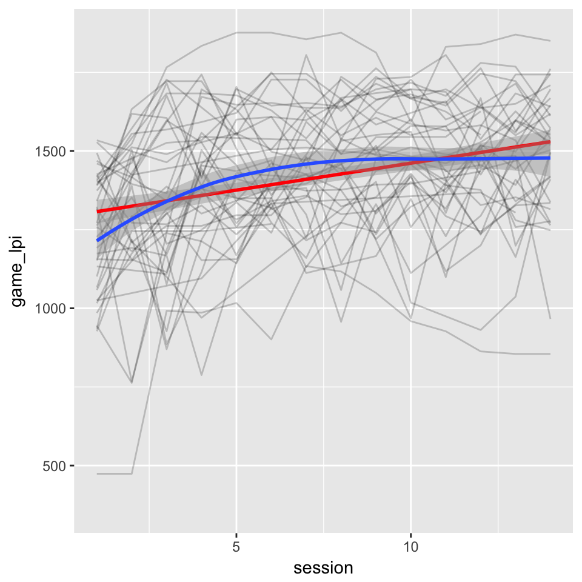

```r
plot_ebb(summer.2015.lumos.df)
```

So let’s take means of those later sessions and see how they go! Note that we are correlating score (higher is better) with ranking (lower is better). So we expect a negative correlation for the “classic” effect.

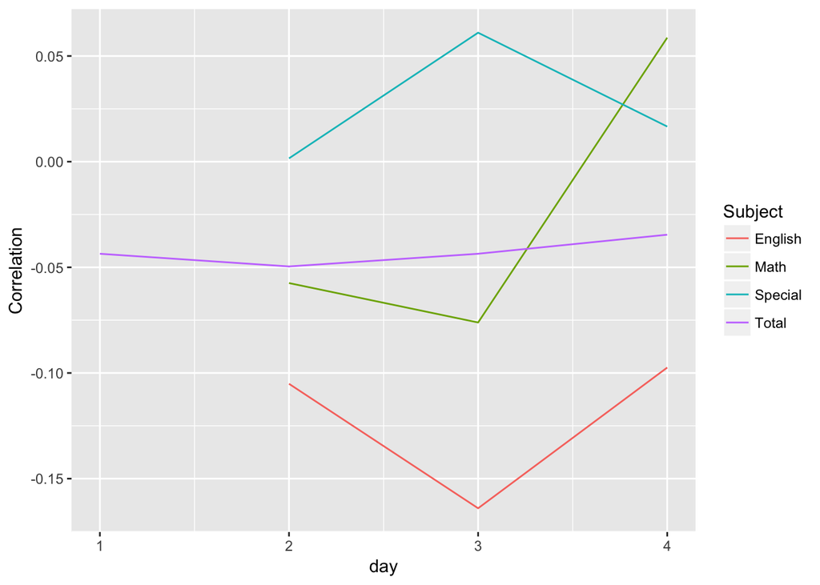

```r
cog_means <- summer.2015.lumos.df %>% filter(game == 107, session >= 8) %>% group_by(KKIid) %>%
                summarise_at(vars(game_lpi), mean)

# a simple rank-correlation
mycor <- function(x,y) {
    cor(x,y, use='na.or.complete', method="kendall")
}

left_join(summer.2015.academic.df, cog_means, by='KKIid') %>%
    group_by(day)  %>%
    summarize(Total=mycor(Total, game_lpi),
              English=mycor(English, game_lpi),
              Math=mycor(Math, game_lpi),
              Special=mycor(Special, game_lpi)) %>%
    gather(key=Subject, value=Correlation, -day) %>%
    na.omit() %>%
    ggplot(aes(x=day, y=Correlation, color=Subject)) + geom_line()
```

Hmm…

# Summer 2016

Our main 2016 sample is 8th graders. This session was run a little better, and kids were able to also play a game based on the classic flanker task (attentional control focus).

```r
summer.2016.lumos.df %>% count(game) %>% arrange(-n) %>% head() %>%
  # Again, add human-readable names
  left_join(summer.2016.lumos.df %>% select(game, game_name) %>% unique(),
            by='game')
```

```
## # A tibble: 6 x 3
##    game     n                        game_name
##   <int> <int>                           <fctr>
## 1   109   484 Lost in Migration: Android Phone
## 2   107   482      Ebb and Flow: Android Phone
## 3   142    22          Train of Thought Mobile
## 4   155    16               Playing Koi Mobile
## 5   146    13            Pinball Recall Mobile
## 6   152    12           Trouble Brewing Mobile
```

With these kids, the learning never stops!

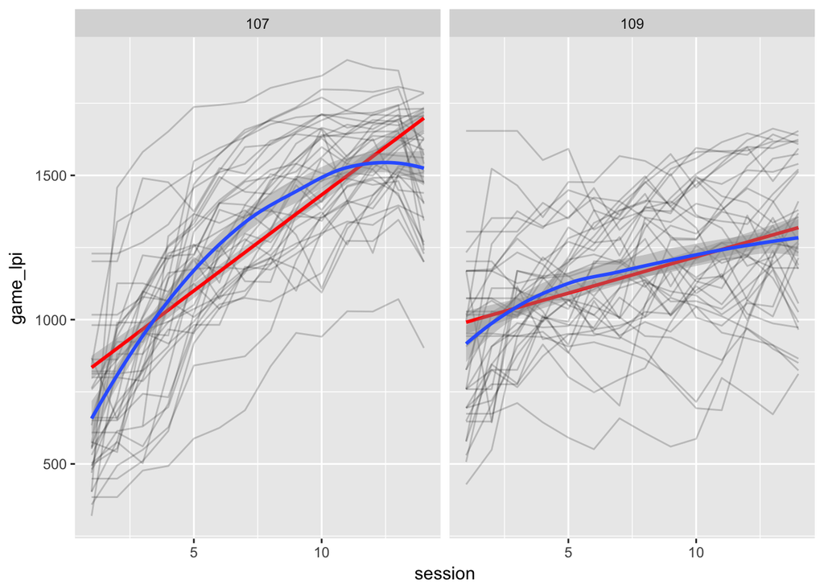

```r
summer.2016.lumos.df %>% filter(game %in% c(107, 109)) %>%
  ggplot(aes(x=session, y=game_lpi)) +
    geom_line(aes(group=KKIid), alpha=0.2) +
    stat_smooth(method='lm', color='red') +
    stat_smooth(method='loess') +
    facet_wrap(~ game)
```

# Sample emotions

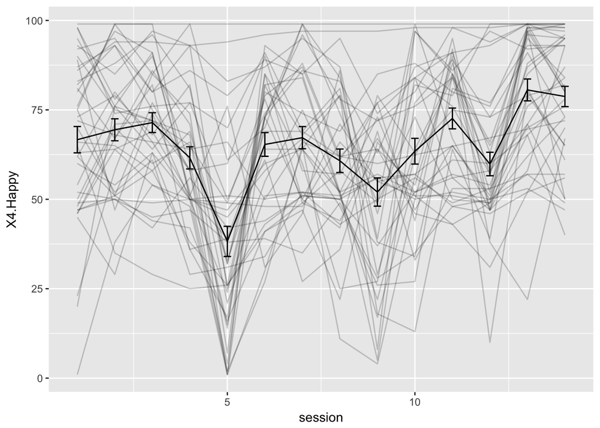

```r
ggplot(summer.2015.odk.df, aes(x=session, y=X4.Happy)) +
      geom_line(aes(group=KKIid), alpha=0.2) +
      stat_summary(fun.y = mean, geom = "line", na.rm=T) +
      stat_summary(fun.data = mean_se, geom = "errorbar", width=0.2, na.rm=T)
```

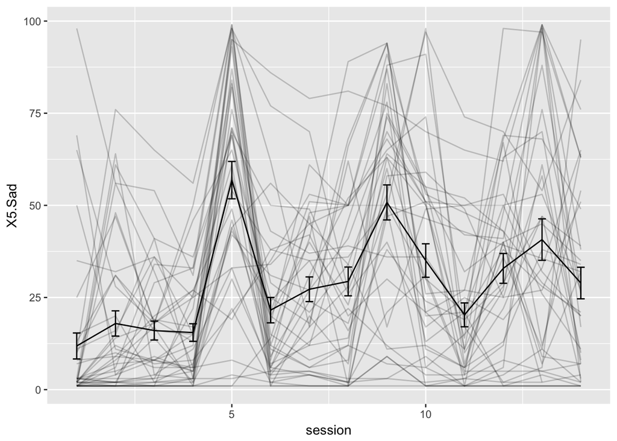

```r
ggplot(summer.2015.odk.df, aes(x=session, y=X5.Sad)) +
      geom_line(aes(group=KKIid), alpha=0.2) +
      stat_summary(fun.y = mean, geom = "line", na.rm=T) +
      stat_summary(fun.data = mean_se, geom = "errorbar", width=0.2, na.rm=T)
```

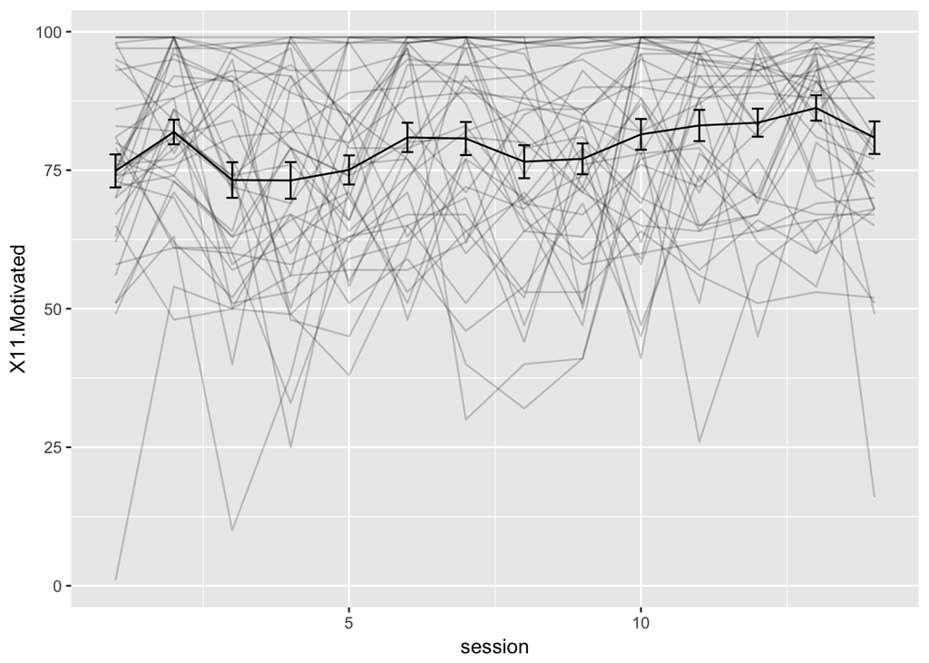

```r
ggplot(summer.2015.odk.df, aes(x=session, y=X11.Motivated)) +
      geom_line(aes(group=KKIid), alpha=0.2) +
      stat_summary(fun.y = mean, geom = "line", na.rm=T) +
      stat_summary(fun.data = mean_se, geom = "errorbar", width=0.2, na.rm=T)
```